# Project 2 - Final

#### Multiple sequence alignment (MSA)

Description: This bioinformatics method using an algorithm to align sequences, which can be used to compare the sequences for similarities in regions of the sequences. This can be helpful for finding similarities in regions of the sequences and identifying any significant differences.

```r
#Read in sequences
library(seqinr)
truffle_18_sequence <- read.fasta("sequence.fasta")
```

```r
#Perform MSA

#Read nucleotide FASTA file as AA sequence
protein_sequence <- readAAStringSet("sequence.fasta")
head(protein_sequence)
```

```
AAStringSet object of length 1:
      width seq                                                         names
[1] 1180472 TGTGACAGGGGCTGGTCAGCGAGCTTCT...AGTACGAGACTCTTAAGGCGGAGTGGTT FN430075.1 Tuber ...
```

```r
#Run MSA
alignment <- msa(truffle_18_sequence)
```

```
Error in checkInputSeq(inputSeqs) : The parameter inputSeq is not valid!
Possible inputs are <character>, <XStringSet>, or a file.
```

### Plotting the Results

#### Volcano plot

Description: This visualization method is a scatterplot that displays points representing the p-value (which represents statistical significance) along the y-axis and fold change (the magnitude of change) of the data along the x-axis. Here, the p-value and fold change values were already provided in the truffle FB & FLM dataset, so those values were plotted. The code was references from this website: https://biocorecrg.github.io/CRG_RIntroduction/volcano-plots.html.

```r
#Extract objects for volcano plot from truffle_dataframe
log2_ratio <- truffle_dataframe$log2ratio
p_value <- truffle_dataframe$pval
```

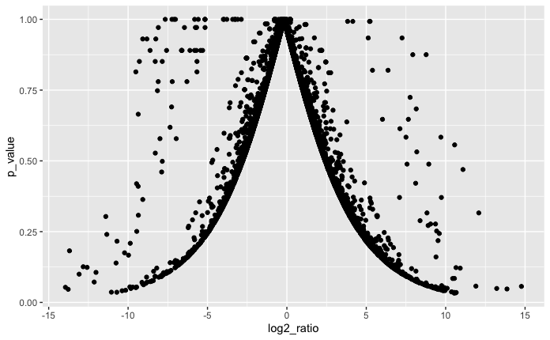

```r
#Create plot
ggplot(data = truffle_dataframe, aes(x = log2_ratio, y = p_value)) + geom_point()
```

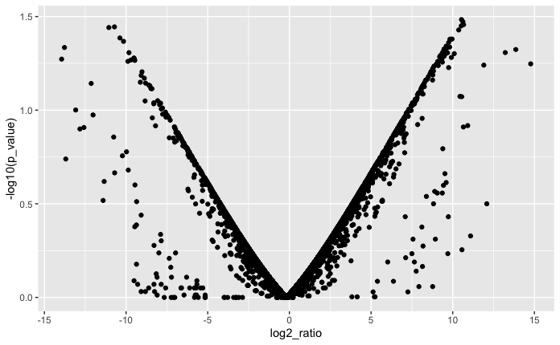

```r
#Convert p-value to -log10(p-value) to get volcano plot to get a volcano plot
ggplot(data = truffle_dataframe, aes(x = log2_ratio, y = -log10(p_value))) + geom_point()
```

#### Principal component analysis (PCA)

Description: PCA is a bioinformatics visualization method that uses principal components to summarize a large amount of data into a smaller data set. This makes it easier to see and analyze the data and to draw comparisons between between various variables. The code used here was referenced from https://www.datacamp.com/tutorial/pca-analysis-r#simple.

```r
#PCA code
truffle.pca <- prcomp(truffle_dataframe[,c(3,4,5,6,7)], center = TRUE, scale = TRUE)
summary(truffle.pca)
```

```
Importance of components:
                          PC1    PC2    PC3     PC4    PC5
Standard deviation     1.5007 1.2327 1.0047 0.37227 0.2837
Proportion of Variance 0.4504 0.3039 0.2019 0.02772 0.0161
Cumulative Proportion  0.4504 0.7543 0.9562 0.98390 1.0000
```

```r
str(truffle.pca)
```

```
List of 5
 $ sdev    : num [1:5] 1.501 1.233 1.005 0.372 0.284
 $ rotation: num [1:5, 1:5] -0.0294 -0.5003 -0.4718 -0.5112 -0.5147 ...
  ..- attr(*, "dimnames")=List of 2
  .. ..$ : chr [1:5] "length" "FB" "FLM" "RPKM_FB" ...
  .. ..$ : chr [1:5] "PC1" "PC2" "PC3" "PC4" ...
 $ center  : Named num [1:5] 1746.5 3121.3 3177.2 28.7 30.3
  ..- attr(*, "names")= chr [1:5] "length" "FB" "FLM" "RPKM_FB" ...
 $ scale   : Named num [1:5] 1185 13495 13667 157 126
  ..- attr(*, "names")= chr [1:5] "length" "FB" "FLM" "RPKM_FB" ...
 $ x       : num [1:7496, 1:5] 0.21489 0.24179 0.08814 -0.32738 0.00552 ...
  ..- attr(*, "dimnames")=List of 2
  .. ..$ : NULL
  .. ..$ : chr [1:5] "PC1" "PC2" "PC3" "PC4" ...
 - attr(*, "class")= chr "prcomp"
```

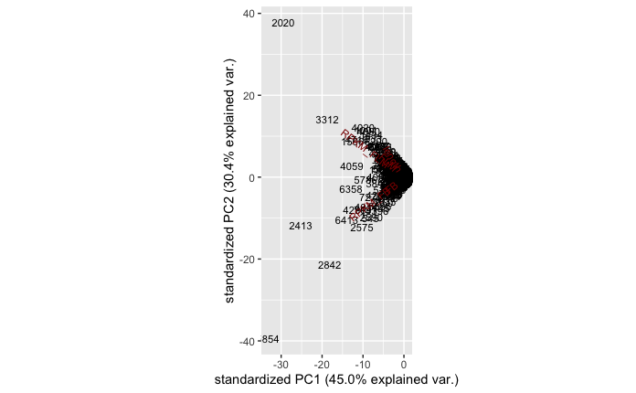

```r
#plot PCA
ggbiplot(truffle.pca, labels = rownames(truffle_dataframe))
```

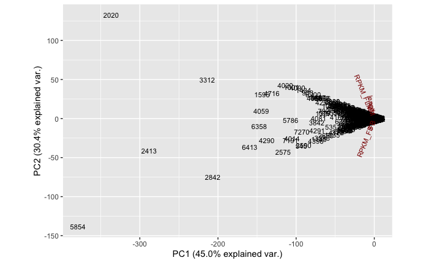

```r
#Plot but scaled
ggbiplot(truffle.pca, labels = rownames(truffle_dataframe), scale = -5)
```